# COVID-19 Vaccination and Death Rates: A Cross-Country Analysis

# About This Report

This analysis began as a team project for STAT 240 (Data Science Modeling I) at UW-Madison. Later, while taking STAT 340 (Data Science Modeling II), I independently revised and expanded it using multiple regression and confounding controls.

**Revision note (November 2026).** The original submission concluded that higher vaccination rates were significantly associated with lower COVID-19 mortality (p < 2.2e-16). On review, I found that those regressions had been fit on daily country-level rows (about 65,000 rows) instead of one observation per country. Repeated measurements of the same country were treated as independent, which made the p-values far smaller than they should have been. This version makes the following changes:

- Fits the models on one row per country (n = 209)
- Log-transforms the skewed outcomes and uses cumulative cases instead of peak daily cases
- Fixes the country filter (South Africa had been excluded by mistake, and some aggregate regions had been kept)
- Adds multiple regression adjusting for population age and income
- Adds a timing analysis comparing vaccination by the end of 2021 with deaths after 2021

The corrected analysis reverses the original conclusion, as described below.

# Introduction

This report examines how COVID-19 vaccination coverage relates to COVID-19 mortality and infection rates across countries. Each observation is a country, and we use linear regression to estimate the association between a country’s cumulative vaccination rate (doses per 100 people) and its cumulative COVID-19 deaths and confirmed cases per million people.

**Research question:** Do countries with higher vaccination coverage have lower reported COVID-19 death and case rates, and does that association remain after accounting for population age and national income?

**Thesis:** Across countries, higher vaccination coverage is *not* associated with lower reported COVID-19 mortality in a simple regression. The raw association is positive, and it is largely explained by confounders: wealthier countries with older populations both vaccinated more and recorded more COVID-19 deaths and cases. After adjusting for age and income, the vaccination coefficient for deaths turns slightly negative but is not statistically significant at $\alpha = 0.05$. Country-level data of this kind therefore cannot by itself show whether vaccines reduce deaths. Individual-level studies are better suited to that question.

# Background

## Data

We use the Our World in Data (OWID) COVID-19 dataset (Mathieu et al., 2021), which compiles official reports from governments and health ministries. The version used here covers 2020-01-01 to 2024-08-14. The variables used are:

| Variable | Meaning |
| --- | --- |
| `total_vaccinations_per_hundred` | Cumulative vaccine doses administered per 100 people (all doses, including boosters, so it can exceed 100) |
| `total_deaths_per_million` | Cumulative confirmed COVID-19 deaths per million people |
| `total_cases_per_million` | Cumulative confirmed COVID-19 cases per million people |
| `aged_65_older` | Share of the population aged 65 or older (%) |
| `gdp_per_capita` | GDP per capita (PPP) |

The `location` column also contains aggregate rows: continents, income groups, the European Union, and the World. These rows have no `continent` value, so we keep only rows where `continent` is present. Each country is then reduced to a single row holding the latest value of each cumulative measure. After removing countries with missing values or zero deaths/cases, **209 countries** remain. We do not trim outliers. Trimming on vaccination totals would remove the most and least populous countries rather than unusual observations.

## A first look: global trends over time

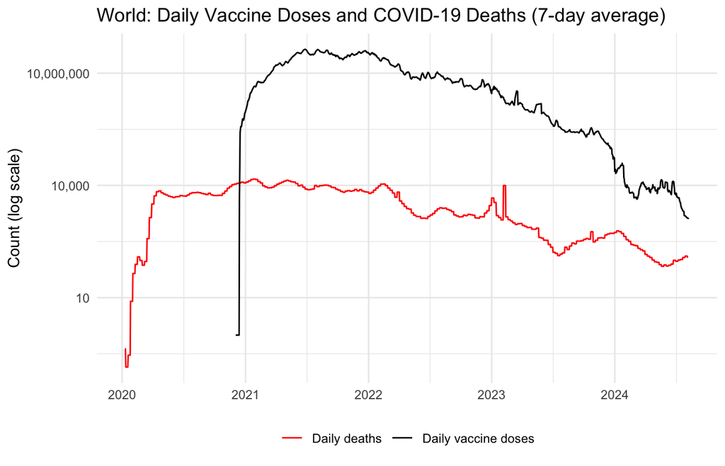

Daily vaccine doses rose sharply in early 2021 and peaked in mid-2021. Daily deaths, however, stayed close to their earlier level through 2021 and declined mainly from 2022 onward. The timing fits the idea that vaccination helped reduce deaths, but other changes happened over the same period, including immunity from prior infection, new variants with different severity (such as Omicron), and better treatment. This pattern alone therefore does not show that vaccines caused the decline. The rest of the report compares countries at a single point in time instead. That approach has its own limitations, discussed below.

# Graphs

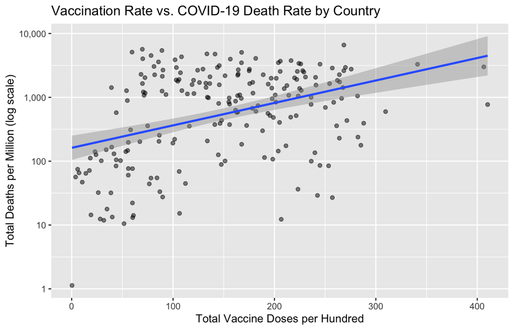

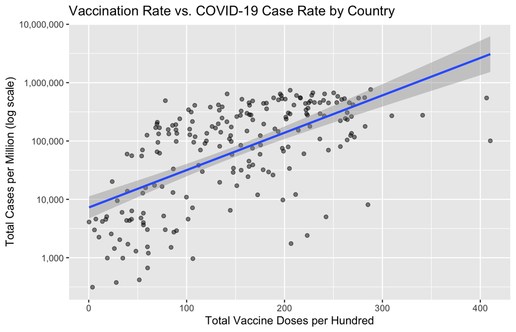

# Analysis

## Model

For country $i$, let $X_i$ be the vaccination rate (doses per hundred) and $Y_i$ the outcome (deaths or cases per million). The simple linear regression model is

$$\log(Y_i) = \beta_0 + \beta_1 X_i +
\epsilon_i, \qquad \epsilon_i \overset{iid}{\sim} N(0, \sigma^2).$$

Because $Y$ is on the log scale, an increase of 10 doses per hundred multiplies the expected outcome by $e^{10\beta_1}$.

## Hypotheses

- $H_0: \beta_1 = 0$ (no linear association between vaccination rate and log outcome)
- $H_a: \beta_1 \neq 0$

We use a significance level of $\alpha = 0.05$. A p-value only measures statistical significance. The *strength* of the association is described by $R^2$ and the size of $\beta_1$.

## Simple regression results

| Model | β (vaccination) | SE | t | p-value | R² | n |
| --- | --- | --- | --- | --- | --- | --- |
| log(deaths/million) ~ vaccination | 0.0081 | 0.0013 | 6.1692 | <1e-04 | 0.1553 | 209 |
| log(cases/million) ~ vaccination | 0.0147 | 0.0013 | 11.3073 | <1e-04 | 0.3818 | 209 |

Both slopes are statistically significant, so we reject $H_0$ for both outcomes. The direction, however, is the **opposite** of what the original hypothesis expected. Every additional 10 doses per hundred is associated with about 8.4% *higher* reported deaths per million (p = <1e-04, $R^2$ = 0.155) and about 15.9% *higher* reported cases per million (p = <1e-04, $R^2$ = 0.382). Vaccination rate alone explains only 16% of the variation in log death rates across countries.

## Residual diagnostics

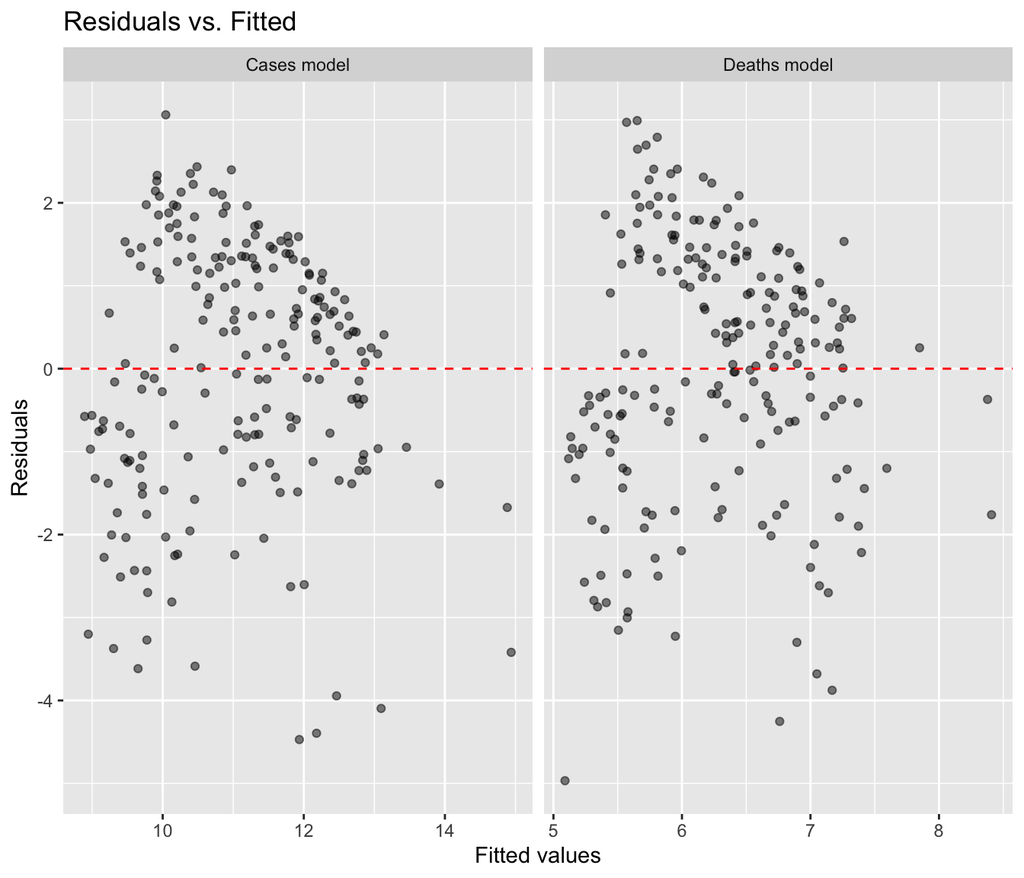

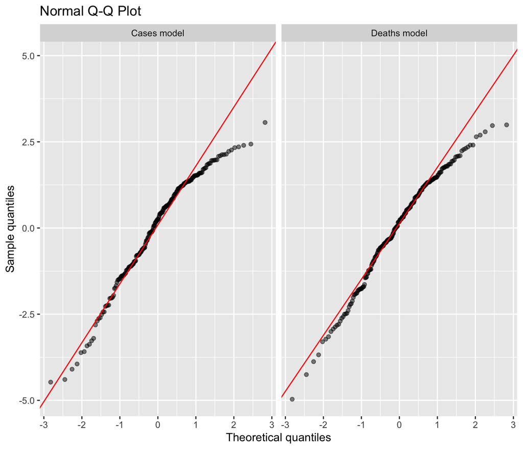

The residual plots show clear structure, so the simple models are not adequate:

- Residuals are mostly negative at low fitted values. Across the middle range, the points split into a band above zero and a band below it. This suggests that an important variable is missing. Countries with similar vaccination rates fall into distinct groups with systematically higher or lower death rates.
- The Q-Q plots bend away from the line in both tails. There is a long lower tail (a few countries report far fewer deaths or cases than predicted) and a short upper tail, so the residuals are left-skewed rather than normal.

With 209 observations, the t-tests are fairly robust to non-normality. The systematic pattern is the bigger concern. It points to omitted variables, which we examine next.

## Why is the association positive? Confounding by age and income

A positive slope does not mean vaccines increase deaths. Countries differ in many ways besides vaccination. Two important differences are:

- **Age structure:** COVID-19 mortality rises steeply with age. Older populations have more deaths, and they were also prioritized for vaccination.
- **National income:** Richer countries had earlier and larger vaccine supplies. They also test more and record deaths more completely, so they *report* more cases and deaths.

| Pair | Correlation |
| --- | --- |
| vaccination vs. % aged 65+ | 0.492 |
| vaccination vs. log GDP per capita | 0.642 |
| log deaths vs. % aged 65+ | 0.670 |
| log deaths vs. log GDP per capita | 0.710 |

Vaccination rate is positively correlated with both age and income, and so is the death rate. Those are the conditions under which a simple regression produces a misleading association. We therefore fit a multiple regression that adjusts for both:

$$\log(Y_i) = \beta_0 + \beta_1
\,\text{Vax}_i + \beta_2 \,\text{Age65}_i + \beta_3 \log(\text{GDP}_i) +
\epsilon_i$$

Adjusted model: log(deaths per million)

| term | estimate | std.error | statistic | p.value |
| --- | --- | --- | --- | --- |
| (Intercept) | -1.7518 | 0.8508 | -2.0591 | 0.041 |
| vax_per_hundred | -0.0027 | 0.0014 | -1.9293 | 0.055 |
| aged_65_older | 0.1053 | 0.0186 | 5.6517 | <1e-04 |
| log(gdp_per_capita) | 0.8078 | 0.1100 | 7.3401 | <1e-04 |

Adjusted model: log(cases per million)

| term | estimate | std.error | statistic | p.value |
| --- | --- | --- | --- | --- |
| (Intercept) | 0.9098 | 0.7507 | 1.2120 | 0.227 |
| vax_per_hundred | 0.0026 | 0.0012 | 2.0798 | 0.039 |
| aged_65_older | 0.0854 | 0.0164 | 5.1934 | <1e-04 |
| log(gdp_per_capita) | 0.9601 | 0.0971 | 9.8882 | <1e-04 |

After adjusting for age and income (n = 178 countries with complete covariates):

- **Deaths:** The vaccination coefficient changes sign to -0.0027, about -2.7% per 10 doses per hundred. Its p-value is 0.055, so at $\alpha = 0.05$ we **fail to reject** $H_0$. Age and income are both strongly significant, and $R^2$ rises from 0.155 to 0.586.
- **Cases:** The vaccination coefficient shrinks to 0.0026 (p = 0.039), and $R^2$ = 0.741. Reported cases depend heavily on testing capacity, which this model does not measure directly. For that reason, we put less weight on the case outcome.

## Accounting for timing

Cumulative deaths include deaths from 2020, before any vaccine was available. A fairer comparison asks whether vaccination coverage by the end of 2021 relates to deaths that happened **after** that date.

Vaccination by end of 2021 vs. log(deaths per million after 2021)

| Model | β (vaccination) | SE | t | p-value | R² | n |
| --- | --- | --- | --- | --- | --- | --- |
| Unadjusted | 0.0215 | 0.0020 | 10.9381 | <1e-04 | 0.4074 | 176 |
| Adjusted for age + GDP | 0.0022 | 0.0026 | 0.8721 | 0.38 | 0.6572 | 176 |

The timing analysis follows the same pattern. The unadjusted slope is positive and highly significant. Once age and income are included, the vaccination coefficient is close to zero and not significant (p = 0.38).

## Summary of hypothesis tests

| Model | β (vaccination) | SE | t | p-value | R² | n | Decision (α = 0.05) |
| --- | --- | --- | --- | --- | --- | --- | --- |
| Deaths: unadjusted | 0.0081 | 0.0013 | 6.1692 | <1e-04 | 0.1553 | 209 | Reject H0 |
| Deaths: adjusted | -0.0027 | 0.0014 | -1.9293 | 0.055 | 0.5861 | 178 | Fail to reject H0 |
| Cases: unadjusted | 0.0147 | 0.0013 | 11.3073 | <1e-04 | 0.3818 | 209 | Reject H0 |
| Cases: adjusted | 0.0026 | 0.0012 | 2.0798 | 0.039 | 0.7414 | 178 | Reject H0 |
| Deaths after 2021: unadjusted | 0.0215 | 0.0020 | 10.9381 | <1e-04 | 0.4074 | 176 | Reject H0 |
| Deaths after 2021: adjusted | 0.0022 | 0.0026 | 0.8721 | 0.38 | 0.6572 | 176 | Fail to reject H0 |

# Interpretation

The simple regressions find a statistically significant association between vaccination rate and both outcomes, but the association is **positive**. Countries with more vaccine doses per person reported more COVID-19 deaths and cases per million. The original hypothesis, that higher vaccination is associated with lower mortality, is therefore not supported by the unadjusted cross-country data.

The positive slope is mostly explained by confounding. Wealthier countries with older populations vaccinated more, have more people at high risk of dying from COVID-19, and test and record deaths more completely. After adjusting for age and GDP, the vaccination coefficient for deaths becomes slightly negative but is not statistically significant. Age and income explain far more of the cross-country variation than vaccination does.

These results do **not** show that vaccines are ineffective. They show that a country-level cross-sectional comparison is a weak design for this question. Drawing conclusions about individuals from group-level data is known as the *ecological fallacy*. Studies that compare vaccinated and unvaccinated individuals within the same population are much better suited to estimating vaccine effectiveness.

## Limitations

1. **Ecological design.** Each observation is a country, so the results describe countries, not individuals, and cannot establish causation.
2. **Reporting differences.** Confirmed deaths and cases depend on testing capacity and death-registration quality. Both vary widely and are correlated with income. Excess mortality would be a more comparable outcome.
3. **Unmeasured confounders.** We adjust only for age and GDP. Other factors are not included: comorbidities, prior infection, non-pharmaceutical interventions, variant timing, and health-care capacity.
4. **Vaccination measure.** `total_vaccinations_per_hundred` counts all doses, including boosters. It does not separate first doses from full or booster coverage, or distinguish vaccine types.
5. **Cumulative outcomes.** Totals mix the pre-vaccine and post-vaccine periods. The timing analysis addresses this only partly.
6. **Missing data.** Countries missing age or GDP data are dropped from the adjusted models, which may not be a random subset.

## Future work

- Use **excess mortality** (`excess_mortality_cumulative_per_million` in the OWID data) as the outcome to reduce reporting bias.
- Add further covariates such as `diabetes_prevalence`, `cardiovasc_death_rate`, `hospital_beds_per_thousand`, and testing rates.
- Use **panel models** that follow each country over time, so that fixed differences between countries are controlled for.
- Compare vaccination strategies, for example rapid versus gradual rollouts, and use dose-specific measures such as `people_fully_vaccinated_per_hundred`.

# References

Mathieu, E., Ritchie, H., Ortiz-Ospina, E. et al. (2021). A global database of COVID-19 vaccinations. *Nature Human Behaviour*, 5, 947–953.

Our World in Data. COVID-19 dataset (`owid-covid-data.csv`). https://github.com/owid/covid-19-data/tree/master/public/data. Data through 2024-08-14.